# Comparison of various implementations of group sequential design with interim analysis

Binbing Yu

2026-05-06

This file compares the implementation of various group sequential design software tools with interim analysis

- AZ futility anlaysis R Shiny tool (https://rstudio-connect.seml.scp.astrazeneca.net/futility/)
- EAST (https://cytel.com/east-horizon/)
- R gsDesign and gsDesign2 packages (https://merck.github.io/gsDesign2/)
- rpact (https://www.rpact.org/)

# 1. Case 1 with only futility assessment at interim

The hypotheses and assumptions, trial design and operational parameters are below. All parameters take the default values in the AZ futility shiny tool except that the time from DCO to futility decision is 0 months instead of 2 months.

```r
control.median <- 12
HR1 <- 0.65
dropout.rate <- -log(0.999)/12   # 0.1% per 12 month
randomization.ratio<-1
alpha <- 0.025
power <- 0.9
N <- 500
accrual.period <- 18
k<-1.5
time.DCO.futility<-0
IA.IF <-0.35
Stopping.Metric.List<-c("Hazard Ratio", "IA Z-statistic", "Predictive Probability", "Conditional Power")
Stopping.Boundary.List<-c(0.3, 0.2, 1, 0.7)
```

## 1.1. AZ futility Shiny tool output

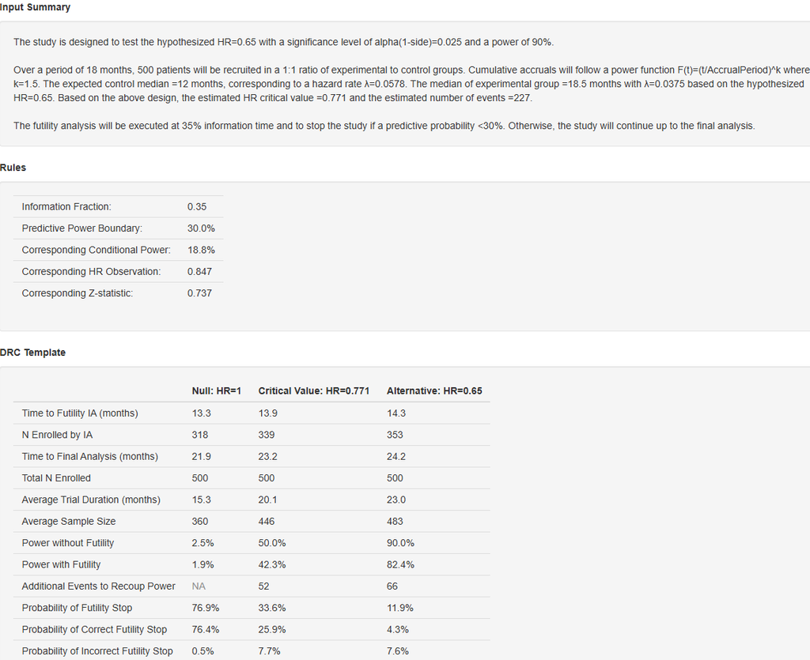

## 1.2. gsDesign/2 implementation

**Input summary** (which does not depend on accrual schedule and baseline hazard rate)

```r
n<-nEvents(hr = HR1, alpha = alpha, beta = 1-power, ratio = randomization.ratio, tbl = TRUE)$n
p.treat <- randomization.ratio / (1 + randomization.ratio)
SE.logHR<-sqrt(1/(n*p.treat*(1-p.treat)))
critical.HR<-exp(-qnorm(1-alpha)*SE.logHR)
```

The number of events n=227 and the critical.HR=0.7709169.

**Rules**

The formula corresponding to equivalent futility stopping rules in various metrics are shown in Page 7 of Futility User Guide. Let $\theta^*$ be the threshold in HR for futility stopping if $\hat HR_{IA}>\theta^*$, the threshold for the other three metrics are formulated as follows:

$$\begin{eqnarray}
\mbox{Z-statistics } Z^*&=&-\log(\theta^*)\sqrt{n_{IA}\cdot
p_T(1-p_T)}\nonumber\\
\mbox{Predictive probability }
PP^*&=&\Phi\left(\left[-\log(\theta^*)\sqrt{n\cdot
p_T(1-p_T)}-z_{1-\alpha}\right]\sqrt{\frac{I_{IA}}{1-I_{IA}}}\right)\nonumber\\
\mbox{Conditional power }
CP^*&=&\Phi\left(\left[-\log(\theta^*)\sqrt{n\cdot
p_T(1-p_T)}-z_{1-\alpha}\right]\sqrt{\frac{1}{1-I_{IA}}}\right)\nonumber
\end{eqnarray}$$
where $n_{IA}$ is the number of events at IA, $p_T=r/(1+r)$ is the proportion of patients in the treatment arm for $r:1$ randomization, $I_{IA}$ is the information fraction at IA.

Given $(n, r, I_{IA}, \alpha)$, where $n$ is total number of events at final analysis, $r:1$ is the randomization ratio of treatment versus control, IA.IF is the information fraction at interim analysis and $\alpha$ is the one-sided alpha level, the threshold values for anyone of the four metrics, i.e, conditional power (CP), predictive power (PP), hazard ratio (HR) and Z-statistics can be converted into other three using the function `convert.futility.stopping.metrics(metric, threshold, n, r, IA.IF, alpha)`. As of now, I cannot find a good implementation of `gsCP` and `gsPP` functions in `R gsDesign`.

```r
metric.list<-c("HR","Z","PP","CP")
n.IA<-n*IA.IF

convert.futility.stopping.metrics<-function(metric, threshold, n, r, IA.IF, alpha) {
  n.IA<-n*IA.IF
  p.treat<-r/(1+r)
  if (metric=="HR") {
    HR <- threshold
    Z.IA <- -log(HR)*sqrt(n.IA*p.treat*(1-p.treat))
    Z.FA <- -log(HR)*sqrt(n*p.treat*(1-p.treat))
    PP <- pnorm((Z.FA-qnorm(1-alpha))*sqrt(IA.IF/(1-IA.IF)))
    CP <- pnorm((Z.FA-qnorm(1-alpha))*sqrt(1/(1-IA.IF)))
  }
  if (metric=="Z") {
    Z.IA <- threshold
    HR <- exp(-Z.IA/sqrt(n.IA*p.treat*(1-p.treat)))
    Z.FA <- -log(HR)*sqrt(n*p.treat*(1-p.treat))
    PP <- pnorm((Z.FA-qnorm(1-alpha))*sqrt(IA.IF/(1-IA.IF)))
    CP <- pnorm((Z.FA-qnorm(1-alpha))*sqrt(1/(1-IA.IF)))
  }
  if (metric=="PP") {
    PP<-threshold
    Z.FA <- qnorm(PP)/sqrt(IA.IF/(1-IA.IF))+qnorm(1-alpha)
    Z.IA <- Z.FA*sqrt(IA.IF)
    HR <- exp(-Z.IA/sqrt(n.IA*p.treat*(1-p.treat)))
    CP <- pnorm((Z.FA-qnorm(1-alpha))*sqrt(1/(1-IA.IF)))
  }
  if (metric=="CP") {
    CP<-threshold
    Z.FA <- qnorm(CP)*sqrt(1-IA.IF)+qnorm(1-alpha)
    Z.IA <- Z.FA*sqrt(IA.IF)
    HR <- exp(-Z.IA/sqrt(n.IA*p.treat*(1-p.treat)))
    PP <- pnorm((Z.FA-qnorm(1-alpha))*sqrt(IA.IF/(1-IA.IF)))
  }
  return (c(HR,Z.IA,PP,CP))
}

futility.threshold<-convert.futility.stopping.metrics(metric="HR",threshold=0.847, n=n,r=1, IA.IF=IA.IF,alpha=alpha)
#convert.futility.stopping.metrics(metric="Z", threshold=0.737, n=n,r=1, IA.IF=IA.IF,alpha=alpha)
convert.futility.stopping.metrics(metric="PP",threshold=0.30,  n=n,r=1, IA.IF=IA.IF,alpha=alpha)
```

```
## [1] 0.8476305 0.7367451 0.3000000 0.1877014
```

```r
#convert.futility.stopping.metrics(metric="CP",threshold=0.20,  n=n,r=1, IA.IF=IA.IF,alpha=alpha)
kable(round(t(futility.threshold),3))%>%add_header_above(c("HR"=1,"Z-statistic"=1,"PP"=1,"CP"=1))%>%column_spec(1:4, width = "3cm")
```

| HR | Z-statistic | PP | CP |
| --- | --- | --- | --- |
| 0.847 | 0.74 | 0.301 | 0.19 |

**DRC Template**

1. Calculate the times for IA and FA based on target # of events (n) as shown in Rows 2 and 4 in AZ R Shiny tool. The time to reach a certain number of events depends on the enrollment (accrual) schedule, failure/event rates for the two treatment arms and dropout rate. In `gsDesign2`, the users need to define `enroll_rate` and `fail_rate`.

|  | HR = 1 | HR = 0.771 | HR = 0.65 |
| --- | --- | --- | --- |
| IA | 13.3 | 13.9 | 14.2 |
| FA | 21.9 | 23.2 | 24.2 |

2. Power with futility and Probability of futility stop

**Note:** The futility bound in R gsDesign2 uses the metric of Z-statistic.

```r
fail_rate <- tibble(stratum = "All",  duration = Inf, fail_rate = log(2) / control.median, hr = HR1, dropout_rate=dropout.rate)

case1.gsd2<-gsDesign2::gs_power_ahr(
  enroll_rate = enroll_rate,
  fail_rate = fail_rate,
  ratio = randomization.ratio,
  event = c(IA.IF,1)*n,
  binding = FALSE,
  upper = gs_spending_bound,
  upar = list(sf = gsDesign::sfLDOF, total_spend = 0.025),
  test_upper = c(FALSE, TRUE),
  test_lower = c(TRUE, FALSE),
  lower = gs_b,
  lpar = c(hrn2z(hr = 1/0.847, n = 80, ratio = 1),  -Inf),
  info_scale = "h0_h1_info"
)

#kable(case1.gsd2$analysis)%>%kable_styling()
case1.gsd2 |>  summary() |>  as_gt()
```

Bound summary for AHR design

AHR approximations of ~HR at bound

| Bound | Z | Nominal p<sup>1</sup> | ~HR at bound<sup>2</sup> | Cumulative boundary crossing probability Alternate hypothesis | Cumulative boundary crossing probability Null hypothesis |
| --- | --- | --- | --- | --- | --- |
| Analysis: 1 Time: 14.2 N: 353 Events: 79.4 AHR: 0.65 Information fraction: 0.35 |  |  |  |  |  |
| Futility | 0.74 | 0.2289 | 0.8465 | 0.1233 | 0.7711 |
| Analysis: 2 Time: 24.2 N: 501 Events: 227 AHR: 0.65 Information fraction: 1 |  |  |  |  |  |
| Efficacy | 1.96 | 0.0250 | 0.7709 | 0.8147 | <sup>3</sup> 0.0195 |

<sup>1</sup> One-sided p-value for experimental vs control treatment. Value < 0.5 favors experimental, > 0.5 favors control.  
<sup>2</sup> Approximate hazard ratio to cross bound.  
<sup>3</sup> Cumulative alpha for final analysis (0.0195) is less than the full alpha (0.025) when the futility bound is non-binding. The smaller value subtracts the probability of crossing a futility bound before crossing an efficacy bound at a later analysis (0.025 - 0.0055 = 0.0195) under the null hypothesis.

## 1.3. rpact implementation

For a fixed sample design, 227 events are required to achieve 0.9 power

```r
getDesignGroupSequential(typeOfDesign = "noEarlyEfficacy",
        sided = 1,
        alpha = 0.025,
        beta = 0.1,
        informationRates = c(IA.IF, 1),
        bindingFutility = FALSE,
        futilityBounds = 0.737) |>
    getPowerSurvival(directionUpper = FALSE,
        median2 = 12,
        hazardRatio = HR1,
        maxNumberOfEvents = n,
        accrualTime = c(0:accrual.period),
        accrualIntensity = monthly.accrual,
        dropoutRate1 = 0.05,
        dropoutRate2 = 0.05,
        dropoutTime = 12) |>
    summary()
```

*Power calculation for a survival endpoint*

Sequential analysis with a maximum of 2 looks (group sequential design), one-sided overall significance level 2.5%. The results were calculated for a two-sample logrank test, H0: hazard ratio = 1, power directed towards smaller values, H1: hazard ratio = 0.65, control median(2) = 12, maximum number of events = 227, accrual time = c(1, 2, 3, 4, 5, 6, 7, 8, 9, 10, 11, 12, 13, 14, 15, 16, 17, 18), accrual intensity = c(7, 12, 16, 18, 21, 23, 25, 27, 29, 30, 32, 33, 35, 36, 37, 39, 40, 41), dropout rate(1) = 0.05, dropout rate(2) = 0.05, dropout time = 12.

| Stage | 1 | 2 |
| --- | --- | --- |
| Planned information rate | 35% | 100% |
| Cumulative alpha spent | 0 | 0.0250 |
| Stage levels (one-sided) | 0 | 0.0250 |
| Efficacy boundary (z-value scale) | Inf | 1.960 |
| Futility boundary (z-value scale) | 0.737 |  |
| Efficacy boundary (t) | 0 | 0.771 |
| Futility boundary (t) | 0.848 |  |
| Cumulative power | 0 | 0.8250 |
| Number of subjects | 356.5 | 501.0 |
| Expected number of subjects under H1 |  | 483.9 |
| Cumulative number of events | 79.4 | 227.0 |
| Expected number of events under H1 |  | 209.5 |
| Analysis time | 14.34 | 24.65 |
| Expected study duration under H1 |  | 23.43 |
| Overall exit probability (under H0) | 0.7694 |  |
| Overall exit probability (under H1) | 0.1184 |  |
| Exit probability for efficacy (under H0) | 0 |  |
| Exit probability for efficacy (under H1) | 0 |  |
| Exit probability for futility (under H0) | 0.7694 |  |
| Exit probability for futility (under H1) | 0.1184 |  |

Legend:

- *(t)*: treatment effect scale

# 2. Case 2 - SOUNDTRACK study design

The statistical design assumptions are below:

  ```
   - IA1: Non-binding futility analysis at 70 events with futility bound (HR>0.916)
   - IA2 and IA3: efficacy assessment with O'Brien-Fleming spending function
  ```

```r
rm(list=ls())
alpha <-0.025
N<-1200
rate <- c(3, 6, 10, 16, 23, 33, 42, 50, 55, 59, 62, 63, 64, 64, 65, 65, 65, 65, 65, 65, 65, 65, 65, 65)
drop.prob<- 0.05
HR1 <- 0.415
mEP.ctrl.m <- 54.01717
IF<-c(0.249,0.851,1)
n<-281
event.list<-IF*n

enroll_rate <- define_enroll_rate(duration = c(rep(1,24)), rate=rate)
# The piecewise HR may be used later
fail_rate <- define_fail_rate(
  duration = Inf,
  fail_rate = log(2) / mEP.ctrl.m,
  hr = HR1,
  dropout_rate = -log(1-drop.prob)/12
)
```

## 2.1. EAST results

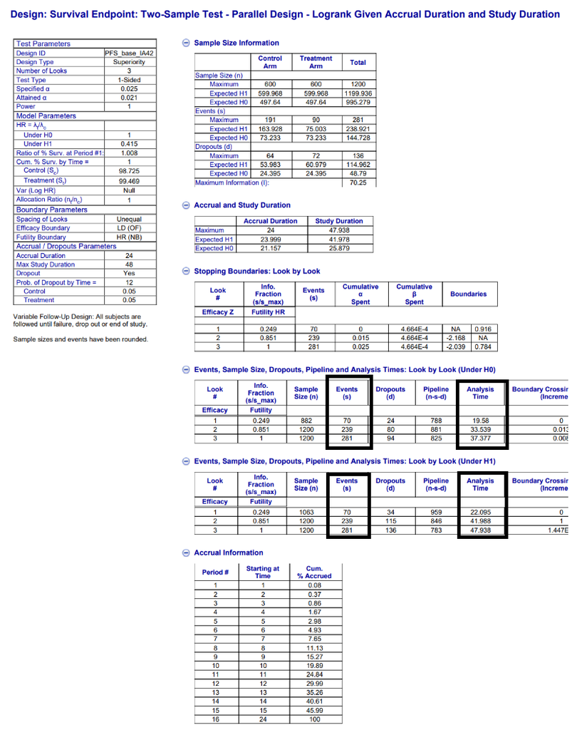

The futility boundary of hazard ratio based on $\beta$-spending function is 0.916

## 2.2. gsDesign2 output

**Note:** The HR futility threshold value in gs_power_ahr function is the reciprocal of the HR threshold (`HR.fut=0.916`) in EAST .

```r
HR.fut <- 0.916
Z.fut<-hrn2z(hr = 1/HR.fut, n = event.list[1], ratio = 1)
```

The z-statistic threshold is 0.367.

```r
case2.gsd2<-gs_power_ahr(
  enroll_rate = enroll_rate,
  fail_rate = fail_rate,
  ratio = 1,
  event = event.list,
  binding = FALSE,
  upper = gs_spending_bound,
  upar = list(sf = gsDesign::sfLDOF, total_spend = alpha),
  info_scale = "h0_h1_info",
  test_upper = c(FALSE, TRUE, TRUE),  # Only test efficacy possible after 1st analysis
  test_lower = c(TRUE, FALSE, FALSE), # Only test futility possible on 1st analysis
  lower = gs_b,
  lpar = c(Z.fut, -Inf, -Inf)
)

#kable(case2.gsd2$analysis, digits=3) %>% kable_styling() %>% column_spec(column=c(2,4),background="yellow")
case2.gsd2 |>  summary() |>  as_gt()
```

Bound summary for AHR design

AHR approximations of ~HR at bound

| Bound | Z | Nominal p<sup>1</sup> | ~HR at bound<sup>2</sup> | Cumulative boundary crossing probability Alternate hypothesis | Cumulative boundary crossing probability Null hypothesis |
| --- | --- | --- | --- | --- | --- |
| Analysis: 1 Time: 21.3 N: 1024.8 Events: 70 AHR: 0.42 Information fraction: 0.25 |  |  |  |  |  |
| Futility | 0.37 | 0.3568 | 0.9160 | 0.0012 | 0.6432 |
| Analysis: 2 Time: 41.3 N: 1200 Events: 239.1 AHR: 0.42 Information fraction: 0.85 |  |  |  |  |  |
| Efficacy | 2.17 | 0.0151 | 0.7556 | 0.9987 | 0.0133 |
| Analysis: 3 Time: 47.2 N: 1200 Events: 281 AHR: 0.42 Information fraction: 1 |  |  |  |  |  |
| Efficacy | 2.04 | 0.0207 | 0.7840 | 0.9987 | <sup>3</sup> 0.0208 |

<sup>1</sup> One-sided p-value for experimental vs control treatment. Value < 0.5 favors experimental, > 0.5 favors control.  
<sup>2</sup> Approximate hazard ratio to cross bound.  
<sup>3</sup> Cumulative alpha for final analysis (0.0208) is less than the full alpha (0.025) when the futility bound is non-binding. The smaller value subtracts the probability of crossing a futility bound before crossing an efficacy bound at a later analysis (0.025 - 0.0042 = 0.0208) under the null hypothesis.

## 2.3. rpact output

```r
getDesignGroupSequential(informationRates = IF,
        futilityBounds = c(Z.fut, -6)) |>
    getPowerSurvival(
        directionUpper = FALSE,
        pi2 = 0.5,
        hazardRatio = HR1,
        maxNumberOfEvents = n,
        eventTime = mEP.ctrl.m,
        accrualTime = c(0:length(rate)),
        accrualIntensity = rate,
        dropoutRate1 = 0.05,
        dropoutRate2 = 0.05,
        dropoutTime = 12) |>
    summary()
```

*Power calculation for a survival endpoint*

Sequential analysis with a maximum of 3 looks (group sequential design), one-sided overall significance level 2.5%. The results were calculated for a two-sample logrank test, H0: hazard ratio = 1, power directed towards smaller values, H1: hazard ratio = 0.415, control pi(2) = 0.5, maximum number of events = 281, event time = 54.017, accrual time = c(1, 2, 3, 4, 5, 6, 7, 8, 9, 10, 11, 12, 13, 14, 15, 16, 17, 18, 19, 20, 21, 22, 23, 24), accrual intensity = c(3, 6, 10, 16, 23, 33, 42, 50, 55, 59, 62, 63, 64, 64, 65, 65, 65, 65, 65, 65, 65, 65, 65, 65), dropout rate(1) = 0.05, dropout rate(2) = 0.05, dropout time = 12.

| Stage | 1 | 2 | 3 |
| --- | --- | --- | --- |
| Planned information rate | 24.9% | 85.1% | 100% |
| Cumulative alpha spent | <0.0001 | 0.0141 | 0.0250 |
| Stage levels (one-sided) | <0.0001 | 0.0140 | 0.0214 |
| Efficacy boundary (z-value scale) | 4.060 | 2.196 | 2.026 |
| Futility boundary (z-value scale) | 0.367 | -Inf |  |
| Efficacy boundary (t) | 0.379 | 0.753 | 0.785 |
| Futility boundary (t) | 0.916 |  |  |
| Cumulative power | 0.3515 | 0.9995 | 0.9995 |
| Number of subjects | 1024.8 | 1200.0 | 1200.0 |
| Expected number of subjects under H1 |  |  | 1138.3 |
| Cumulative number of events | 70.0 | 239.1 | 281.0 |
| Expected number of events under H1 |  |  | 179.6 |
| Analysis time | 21.31 | 41.31 | 47.25 |
| Expected study duration under H1 |  |  | 34.27 |
| Overall exit probability (under H0) | 0.6432 | 0.0124 |  |
| Overall exit probability (under H1) | 0.3520 | 0.6480 |  |
| Exit probability for efficacy (under H0) | <0.0001 | 0.0124 |  |
| Exit probability for efficacy (under H1) | 0.3515 | 0.6480 |  |
| Exit probability for futility (under H0) | 0.6432 | 0 |  |
| Exit probability for futility (under H1) | 0.0005 | <0.0001 |  |

Legend:

- *(t)*: treatment effect scale

# 3. Case 3 - AZD0120 study design with non-proportional hazards

The control median is 15.8 month. The hazard ratio (HR) of treatment vs. control is 4/3 before 2 months and 0.4 after 2 months so that the PFS cross-over time is about 3 months. The design is to find out the sample size (number of patients) based on the target power, survival assumption and enrollment schedule.

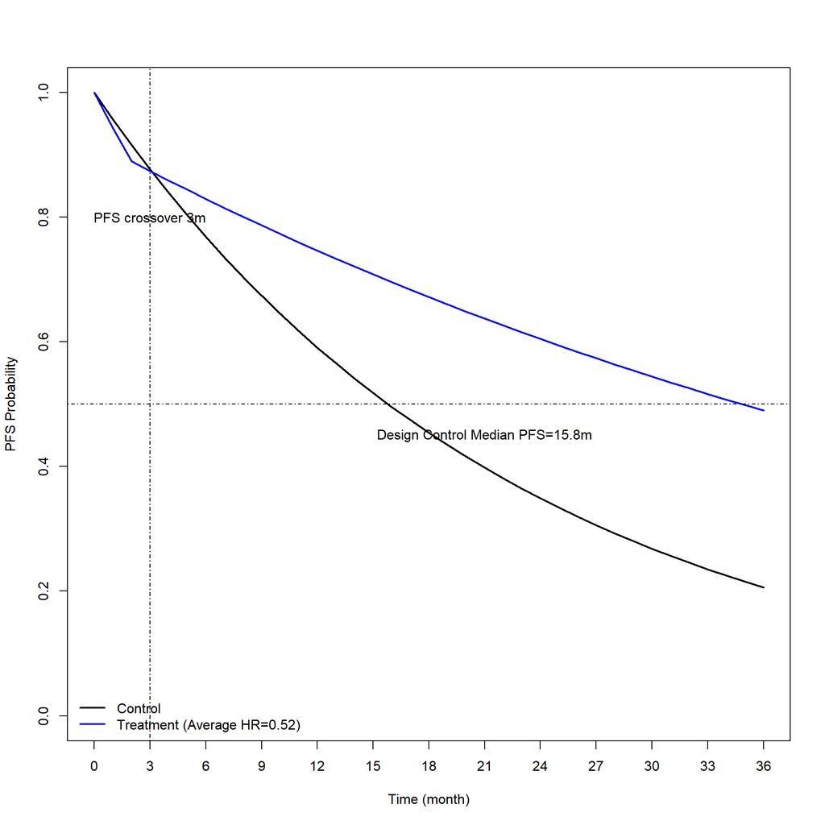

```r
times<-0:36
control.median<-15.8
control.PFS<-1-pexp(times,rate=log(2)/control.median)
sexp.delay<-function(time, rate, tau, HR) {
  (1-pexp(time,rate=rate))*(time<=tau)+(1-pexp(tau,rate=rate))^(1-HR)*(1-pexp(time,rate=rate))^(HR)*(time>tau)
}
treatment.PFS<-sexp.delay(times,log(2)/(control.median/(4/3)),2,0.3)
plot(times,control.PFS,type="l",ylim=c(0,1),xlab="Time (month)",ylab="PFS Probability",lwd=2,xaxt="n")
lines(times,treatment.PFS,type="l",col="blue",pch=16,lwd=2)
axis(1,at=3*(0:12))
abline(h=0.5,lty=4)
abline(v=3,lty=4)
legend("bottomleft",col=c("black","blue"),lwd=2,lty=1,bty="n", legend=c("Control","Treatment (Average HR=0.52)"))
text(x=21,y=0.45,"Design Control Median PFS=15.8m")
text(x=3,y=0.8,"PFS crossover 3m")
```

## 3.1. gsDesign2 results

```r
alpha<-0.025
beta<-0.1  # 1-power
monthly.enrollment<-c(1, 3, 4, 6, 8, 11, 14, 17, 21, 22, 25, rep(28, 5))
cumulative.enrollment<-cumsum(monthly.enrollment)
enrollment.duration<-length(monthly.enrollment)
lag.time <- 2
HR1<-c(4/3,0.4)
drop.prob<-0.05
analysis.time<-c(18,24,30)
futility.null.prob<-0.36
Z.fut<-qnorm(futility.null.prob)
N<-cumulative.enrollment[enrollment.duration]

enroll_rate <- define_enroll_rate(
    duration = rep(1,enrollment.duration),
    rate=monthly.enrollment
)

PFS_fail_rate <- define_fail_rate(
    duration = c(lag.time, Inf),
    fail_rate = log(2) / control.median,
    hr = HR1,
    dropout_rate = -log(1-drop.prob)/12           # 5% dropout in 1 year (12m)
  )

case3.gsd2 <- gs_design_ahr(
    alpha = alpha,
    beta = beta,
    enroll_rate = enroll_rate,
    fail_rate = PFS_fail_rate,
    analysis_time = analysis.time,
    upper = gs_spending_bound, # Spending function bound for efficacy
    upar = list(sf = gsDesign::sfLDOF, total_spend = alpha),
    test_upper = c(FALSE,TRUE,TRUE),
    lower = gs_b,
    lpar = c(Z.fut, -Inf,-Inf), # futility bound at IA1
    info_scale = "h0_h1_info"
  )
 case3.gsd2 |>  summary() |>  as_gt()
```

Bound summary for AHR design

AHR approximations of ~HR at bound

| Bound | Z | Nominal p<sup>1</sup> | ~HR at bound<sup>2</sup> | Cumulative boundary crossing probability Alternate hypothesis | Cumulative boundary crossing probability Null hypothesis |
| --- | --- | --- | --- | --- | --- |
| Analysis: 1 Time: 18 N: 270.9 Events: 60.9 AHR: 0.67 Information fraction: 0.51 |  |  |  |  |  |
| Futility | -0.36 | 0.6400 | 1.0962 | 0.0350 | 0.3600 |
| Analysis: 2 Time: 24 N: 270.9 Events: 93.4 AHR: 0.56 Information fraction: 0.78 |  |  |  |  |  |
| Efficacy | 2.28 | 0.0114 | 0.6242 | 0.6408 | 0.0114 |
| Analysis: 3 Time: 30 N: 270.9 Events: 119.2 AHR: 0.52 Information fraction: 1 |  |  |  |  |  |
| Efficacy | 2.02 | 0.0217 | 0.6906 | 0.9000 | 0.0250 |

<sup>1</sup> One-sided p-value for experimental vs control treatment. Value < 0.5 favors experimental, > 0.5 favors control.  
<sup>2</sup> Approximate hazard ratio to cross bound.

## 3.2. rpact results

```r
event.list<-ceiling(case3.gsd2$analysis$event)
IF<-event.list/event.list[3]

case3.rpact<-getDesignGroupSequential(informationRates = IF,
        typeOfDesign = "asOF",
        sided = 1,
        alpha = alpha,
        futilityBounds = c(Z.fut, -6))

getSimulationSurvival(case3.rpact,
        piecewiseSurvivalTime = c(0, lag.time),
        lambda2 = log(2)/control.median*c(1,1), # haz rate in control
        lambda1 = log(2)/control.median*c(4/3,0.4), # haz rate in treatment
        dropoutRate1 = drop.prob,
        dropoutRate2 = drop.prob,
        dropoutTime = 12,
        accrualTime = c(0, 1:enrollment.duration),
        accrualIntensity = monthly.enrollment,
        #accrualIntensityType = "relative",
        plannedEvents = event.list,
        directionUpper = FALSE,
        maxNumberOfSubjects = sum(monthly.enrollment),
        maxNumberOfIterations = 20000,
        maxNumberOfRawDatasetsPerStage = 1,
        seed = 1234
)
```

*Simulation of survival data (group sequential design)*

*Design parameters*

- *Information rates*: 0.508, 0.783, 1.000
- *Critical values*: 2.935, 2.298, 2.023
- *Futility bounds (non-binding)*: -0.358, -Inf
- *Cumulative alpha spending*: 0.001668, 0.011326, 0.025000
- *Local one-sided significance levels*: 0.001668, 0.010792, 0.021522
- *Significance level*: 0.0250
- *Test*: one-sided

*User defined parameters*

- *Maximum number of iterations*: 20000
- *Seed*: 1234
- *Direction upper*: FALSE
- *Planned cumulative events*: 61, 94, 120
- *Maximum number of subjects*: 272
- *Accrual time*: 1.00, 2.00, 3.00, 4.00, 5.00, 6.00, 7.00, 8.00, 9.00, 10.00, 11.00, 12.00, 13.00, 14.00, 15.00, 16.00
- *Accrual intensity*: 1.0, 3.0, 4.0, 6.0, 8.0, 11.0, 14.0, 17.0, 21.0, 22.0, 25.0, 28.0, 28.0, 28.0, 28.0, 28.0
- *Drop-out rate (1)*: 0.050
- *Drop-out rate (2)*: 0.050
- *Piecewise survival times*: 0.00, 2.00
- *lambda(1)*: 0.0585, 0.0175
- *lambda(2)*: 0.0439, 0.0439
- *Delayed response enabled*: TRUE

*Default parameters*

- *Planned allocation ratio*: 1
- *Conditional power*: NA
- *Drop-out time*: 12.00
- *Theta H0*: 1
- *Allocation 1*: 1
- *Allocation 2*: 1
- *kappa*: 1

*Results*

- *Hazard ratio*: 1.333, 0.400
- *Analysis time [1]*: 18.02
- *Analysis time [2]*: 24.00
- *Analysis time [3]*: 29.63
- *Expected study duration*: 25.29
- *Events not achieved [1]*: 0.000
- *Events not achieved [2]*: 0.000
- *Events not achieved [3]*: 0.000
- *Cumulative number of events [1]*: 61
- *Cumulative number of events [2]*: 94
- *Cumulative number of events [3]*: 120
- *Iterations [1]*: 20000
- *Iterations [2]*: 17825
- *Iterations [3]*: 6504
- *Overall reject*: 0.9027
- *Reject per stage [1]*: 0.07135
- *Reject per stage [2]*: 0.56605
- *Reject per stage [3]*: 0.26530
- *Overall futility stop*: 0.0374
- *Futility stop per stage [1]*: 0.0374
- *Futility stop per stage [2]*: 0.0000
- *Early stop*: 0.6748
- *Expected number of subjects*: 272
- *Expected number of events*: 98.9
- *Number of subjects [1]*: 271.9
- *Number of subjects [2]*: 272
- *Number of subjects [3]*: 272
- *Conditional power (achieved) [1]*: NA
- *Conditional power (achieved) [2]*: 0.3276
- *Conditional power (achieved) [3]*: 0.4672

*Legend*

- *(i)*: values of treatment arm i
- *[k]*: values at stage k